# Homework 6: Simulating and Fitting Data Distributions

Helaina Stergas

2/19/2020

## Illustrating Data Distributions with Fake Data

```r
library(ggplot2) # for graphics
library(MASS) # for maximum likelihood estimation
```

Read in data vector

```r
# quick and dirty, a truncated normal distribution to work on the solution set

z <- rnorm(n=3000,mean=0.2)
z <- data.frame(1:3000,z)
names(z) <- list("ID","myVar")
z <- z[z$myVar>0,]
str(z)
```

```
## 'data.frame':    1719 obs. of  2 variables:
##  $ ID   : int  1 2 3 4 6 7 10 11 12 14 ...
##  $ myVar: num  0.655 0.934 2.482 1.604 0.183 ...
```

```r
summary(z$myVar)
```

```
##    Min. 1st Qu.  Median    Mean 3rd Qu.    Max.
## 0.00005 0.32694 0.73911 0.85258 1.26692 3.86660
```

Plot a histogram of the data

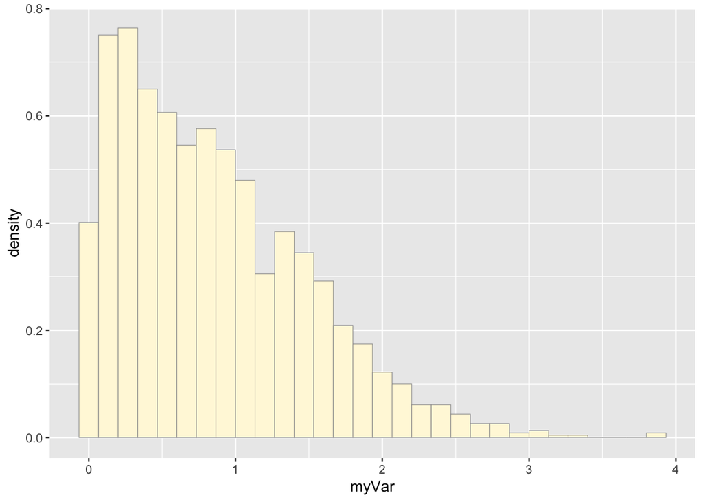

```r
p1 <- ggplot(data=z, aes(x=myVar, y=..density..)) +
  geom_histogram(color="grey60",fill="cornsilk",size=0.2)
# ggplot has more graphics than qplot (used in lecture), plotting x as myVar data and y is rescaled as density, so the area under the histogram = 1
print(p1)
```

Add empirical density curve

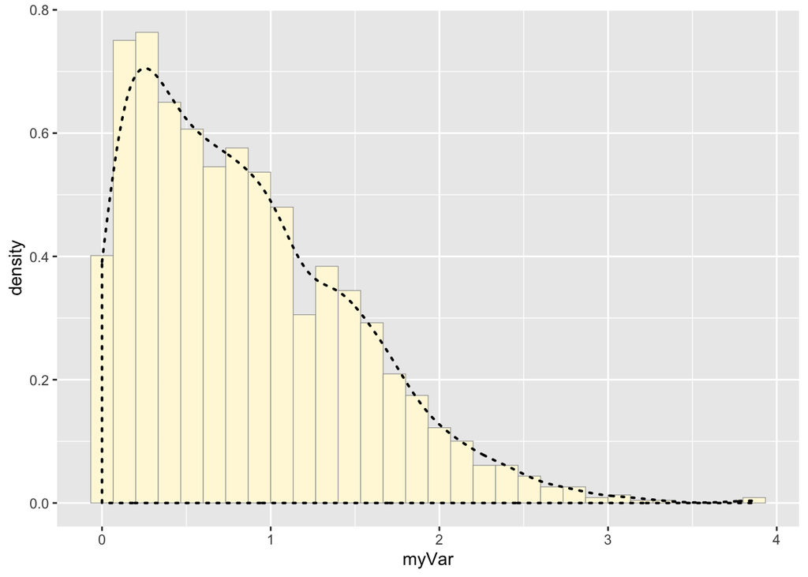

```r
# curve that is fitted to the histogram to smooth out the shape of the graph, does not assume any distribution
p1 <-  p1 +  geom_density(linetype="dotted",size=0.75)
print(p1)
```

Get maximum likelihood paramaters for normal

```r
# fit a normal distribution to the data, and estimate the parameters mean and variance
normPars <- fitdistr(z$myVar,"normal")
print(normPars)
```

```
##       mean          sd
##   0.85258245   0.63975037
##  (0.01543024) (0.01091083)
```

```r
str(normPars)
```

```
## List of 5
##  $ estimate: Named num [1:2] 0.853 0.64
##   ..- attr(*, "names")= chr [1:2] "mean" "sd"
##  $ sd      : Named num [1:2] 0.0154 0.0109
##   ..- attr(*, "names")= chr [1:2] "mean" "sd"
##  $ vcov    : num [1:2, 1:2] 0.000238 0 0 0.000119
##   ..- attr(*, "dimnames")=List of 2
##   .. ..$ : chr [1:2] "mean" "sd"
##   .. ..$ : chr [1:2] "mean" "sd"
##  $ n       : int 1719
##  $ loglik  : num -1671
##  - attr(*, "class")= chr "fitdistr"
```

```r
normPars$estimate["mean"] # note structure of getting a named attribute
```

```
##      mean
## 0.8525825
```

Plot normal probability density

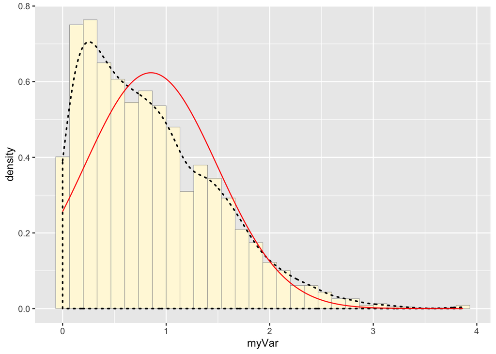

```r
meanML <- normPars$estimate["mean"] # creating a variable for the parameter estimate of "mean" from our data from above
sdML <- normPars$estimate["sd"] # creating a variable from the "normPars" estimate for standard deviation from above

xval <- seq(0,max(z$myVar),len=length(z$myVar)) # creating an x variable to use in "stat_function" for our data from "myVar"

# stat_function superimposes a function on top of an existing plot
 stat <- stat_function(aes(x = xval, y = ..y..), fun = dnorm, colour="red", n = length(z$myVar), args = list(mean = meanML, sd = sdML)) # aes = map plot or plot to fit the new curve to; fun = function used to create the new curve, in this case, we are using the normal distribution "dnorm"; set color of the curve with colour; n = number of points; args =  additional arguments the curve must follow, here we want the mean and sd of our normal distribution estimate from our data found above
 p1 + stat # adding our new normal distribution line to our "p1" plot of the histogram of our data.
```

```r
 # this has used the normal distribution estimates of mean and standard deviation from our data to create a normal distribution curve.

 # note: the normal distribution doesnt fit our data too well - there is a biased mean here
```

Plot exponential probability density

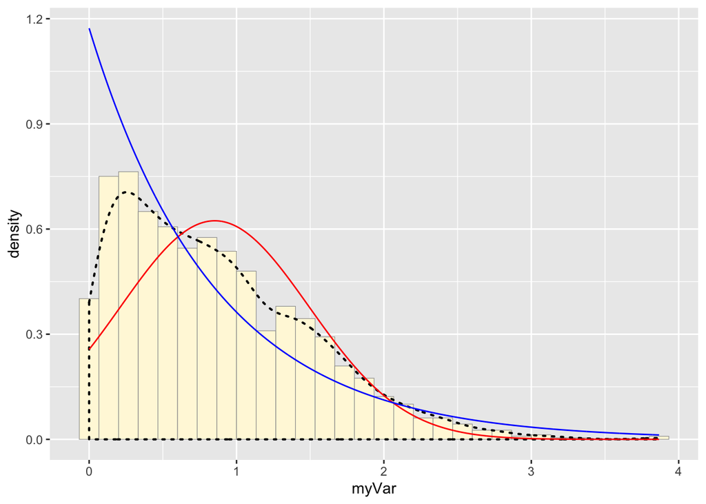

```r
expoPars <- fitdistr(z$myVar,"exponential") # estimating exponential probability parameters
rateML <- expoPars$estimate["rate"] # pulling out the parameter "rate"

stat2 <- stat_function(aes(x = xval, y = ..y..), fun = dexp, colour="blue", n = length(z$myVar), args = list(rate=rateML))
# "dexp" is the function for exponential distribution; constraining our "dexp" curve to the rate estimate found above
 p1 + stat + stat2
```

```r
 # exponential probability doesnt fit too well either
```

Plot uniform probability density

```r
# here we dont need to use fitdistr, because the parameters are just the min and max values of the data
stat3 <- stat_function(aes(x = xval, y = ..y..), fun = dunif, colour="darkgreen", n = length(z$myVar), args = list(min=min(z$myVar), max=max(z$myVar)))
 p1 + stat + stat2 + stat3
```

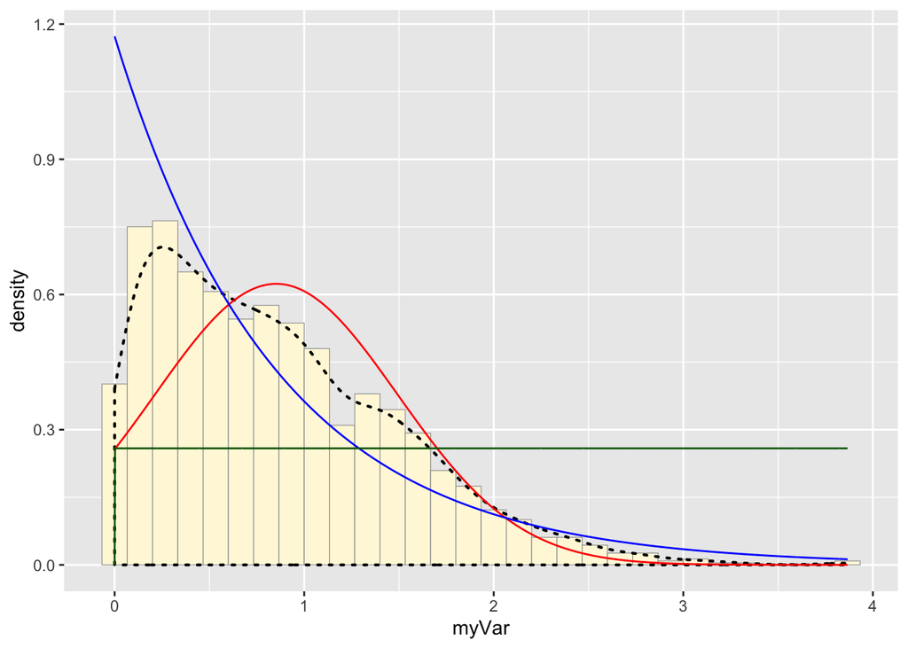

Plot gamma probability density

```r
gammaPars <- fitdistr(z$myVar,"gamma")
shapeML <- gammaPars$estimate["shape"]
rateML <- gammaPars$estimate["rate"]

stat4 <- stat_function(aes(x = xval, y = ..y..), fun = dgamma, colour="brown", n = length(z$myVar), args = list(shape=shapeML, rate=rateML))
 p1 + stat + stat2 + stat3 + stat4
```

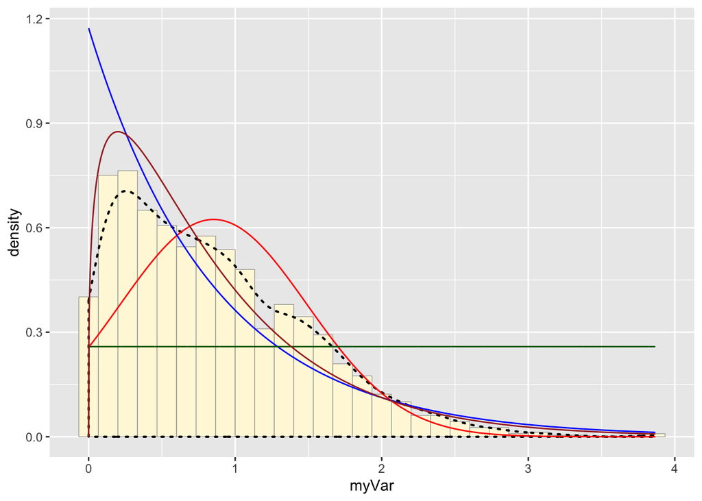

Plot beta probability density

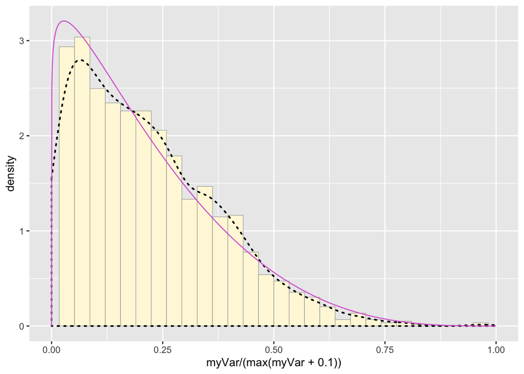

```r
# this one has to be shown in its own plot because the original data needs to be rescaled between 0 and 1
pSpecial <- ggplot(data=z, aes(x=myVar/(max(myVar + 0.1)), y=..density..)) +
  geom_histogram(color="grey60",fill="cornsilk",size=0.2) +
  xlim(c(0,1)) +
  geom_density(size=0.75,linetype="dotted")

betaPars <- fitdistr(x=z$myVar/max(z$myVar + 0.1),start=list(shape1=1,shape2=2),"beta")
shape1ML <- betaPars$estimate["shape1"]
shape2ML <- betaPars$estimate["shape2"]

statSpecial <- stat_function(aes(x = xval, y = ..y..), fun = dbeta, colour="orchid", n = length(z$myVar), args = list(shape1=shape1ML,shape2=shape2ML))
pSpecial + statSpecial
```

## Simulating and fitting data distributions - my data

Read in my data

```r
z <- read.table("SampleData_eyediam.bodylength_WT.csv",header=TRUE,sep=",", stringsAsFactors=FALSE)
str(z)
```

```
## 'data.frame':    24 obs. of  3 variables:
##  $ ID                : int  1 2 3 4 5 6 7 8 9 10 ...
##  $ Genotype          : chr  " CCLL" " CCLL" " CCLL" " CCLL" ...
##  $ EyeDiam.BodyLength: num  0.0804 0.0863 0.083 0.0876 0.0858 ...
```

```r
summary(z)
```

```
##        ID          Genotype         EyeDiam.BodyLength
##  Min.   : 1.00   Length:24          Min.   :0.07454
##  1st Qu.: 6.75   Class :character   1st Qu.:0.08150
##  Median :12.50   Mode  :character   Median :0.08560
##  Mean   :12.50                      Mean   :0.08423
##  3rd Qu.:18.25                      3rd Qu.:0.08793
##  Max.   :24.00                      Max.   :0.09199
```

```r
names(z)[3] <- "myVar" # naming my variable 3 "myVar" to use the code...
names(z)
```

```
## [1] "ID"       "Genotype" "myVar"
```

Run all code above on my data…  
Plot histogram:

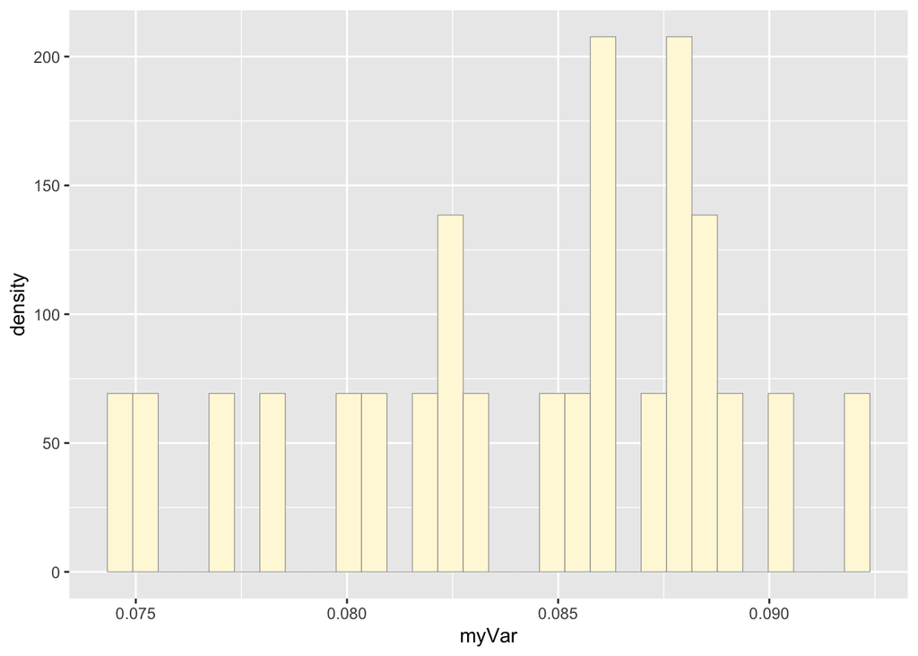

```r
p1 <- ggplot(data=z, aes(x=myVar, y=..density..)) +
  geom_histogram(color="grey60",fill="cornsilk",size=0.2)
print(p1)
```

Adding empirical density curve:

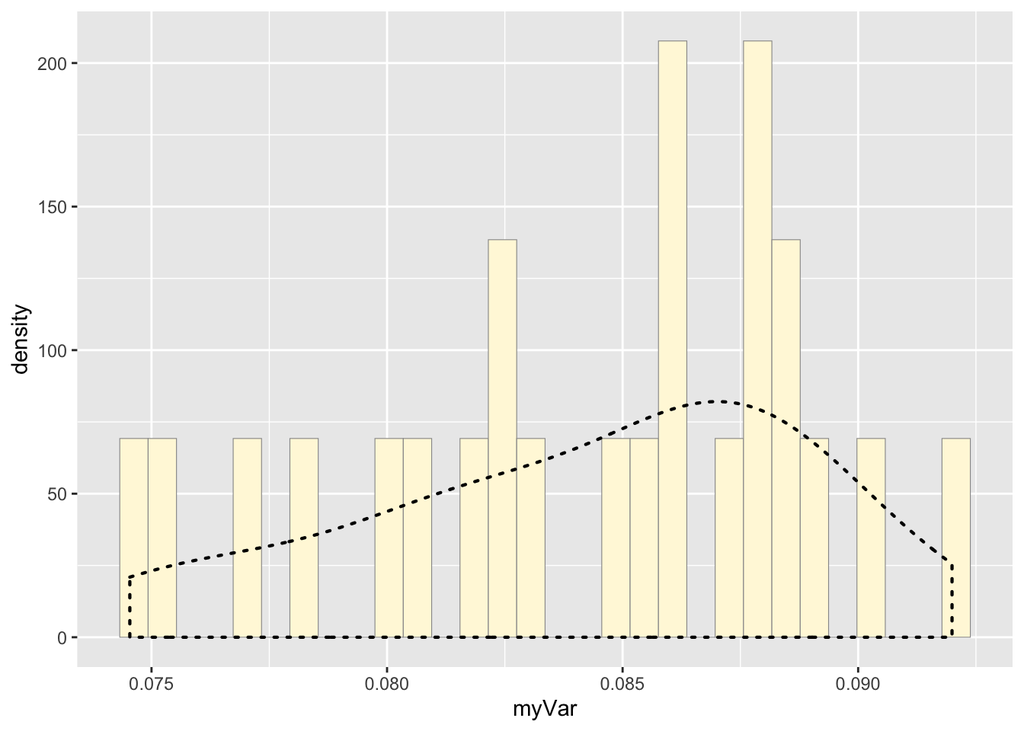

```r
p1 <-  p1 +  geom_density(linetype="dotted",size=0.75)
print(p1)
```

Get maximum likelihood parameters for normal:

```r
normPars <- fitdistr(z$myVar,"normal")
print(normPars)
```

```
##        mean            sd
##   0.0842348529   0.0046532551
##  (0.0009498417) (0.0006716395)
```

```r
str(normPars)
```

```
## List of 5
##  $ estimate: Named num [1:2] 0.08423 0.00465
##   ..- attr(*, "names")= chr [1:2] "mean" "sd"
##  $ sd      : Named num [1:2] 0.00095 0.000672
##   ..- attr(*, "names")= chr [1:2] "mean" "sd"
##  $ vcov    : num [1:2, 1:2] 9.02e-07 0.00 0.00 4.51e-07
##   ..- attr(*, "dimnames")=List of 2
##   .. ..$ : chr [1:2] "mean" "sd"
##   .. ..$ : chr [1:2] "mean" "sd"
##  $ n       : int 24
##  $ loglik  : num 94.8
##  - attr(*, "class")= chr "fitdistr"
```

```r
normPars$estimate["mean"] # note structure of getting a named attribute
```

```
##       mean
## 0.08423485
```

Plot normal probability density:

```r
meanML <- normPars$estimate["mean"]
sdML <- normPars$estimate["sd"]

xval <- seq(0,max(z$myVar),len=length(z$myVar))

 stat <- stat_function(aes(x = xval, y = ..y..), fun = dnorm, colour="red", n = length(z$myVar), args = list(mean = meanML, sd = sdML))
 p1 + stat
```

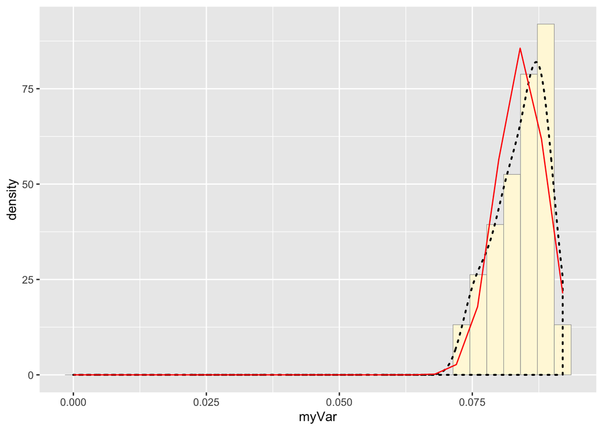

Plot exponential probability density:

```r
expoPars <- fitdistr(z$myVar,"exponential")
rateML <- expoPars$estimate["rate"]

stat2 <- stat_function(aes(x = xval, y = ..y..), fun = dexp, colour="blue", n = length(z$myVar), args = list(rate=rateML))
 p1 + stat + stat2
```

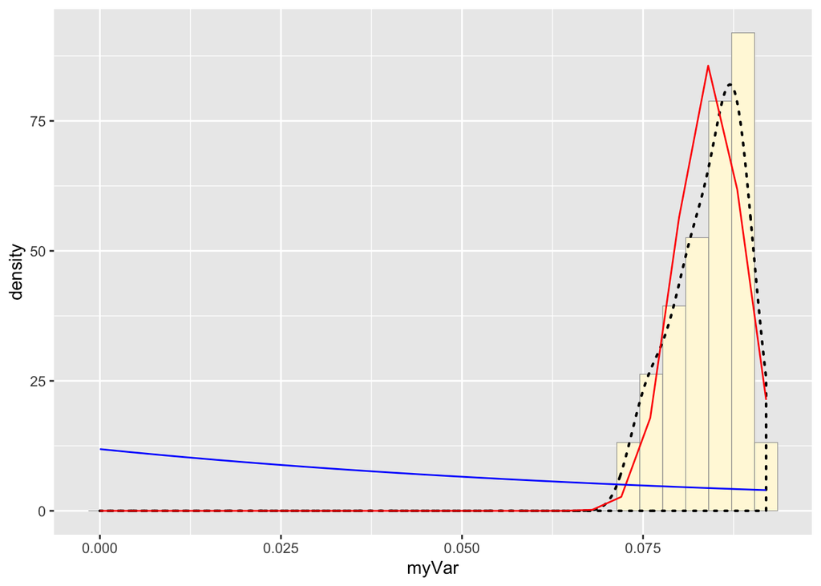

Plot uniform probability density:

```r
stat3 <- stat_function(aes(x = xval, y = ..y..), fun = dunif, colour="darkgreen", n = length(z$myVar), args = list(min=min(z$myVar), max=max(z$myVar)))
 p1 + stat + stat2 + stat3
```

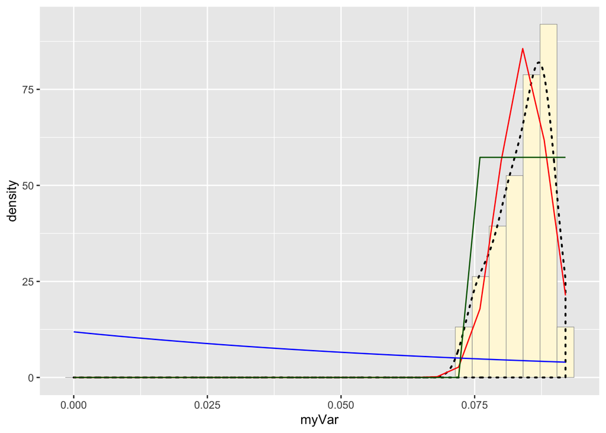

Plot gamma probability density:

```r
gammaPars <- fitdistr(z$myVar,"gamma")
shapeML <- gammaPars$estimate["shape"]
rateML <- gammaPars$estimate["rate"]

stat4 <- stat_function(aes(x = xval, y = ..y..), fun = dgamma, colour="brown", n = length(z$myVar), args = list(shape=shapeML, rate=rateML))
 p1 + stat + stat2 + stat3 + stat4
```

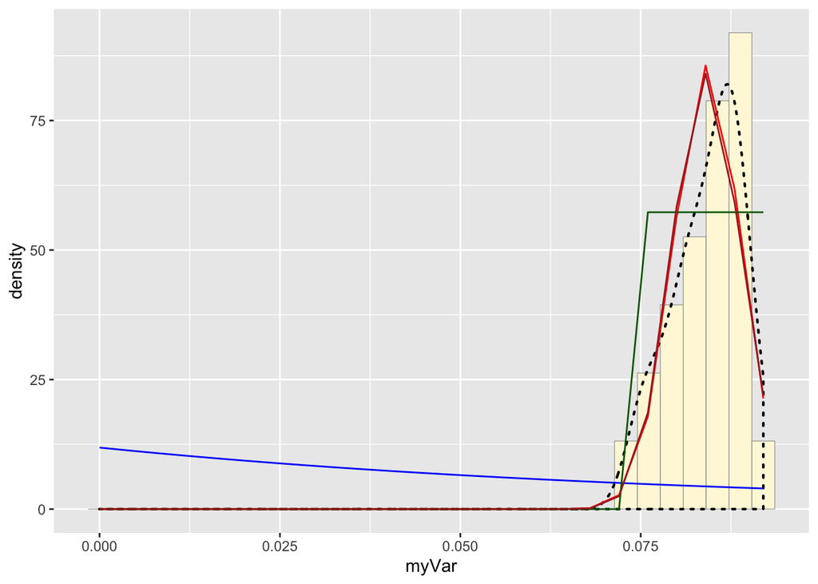

Plot beta probability distribution:

```r
pSpecial <- ggplot(data=z, aes(x=myVar/(max(myVar + 0.1)), y=..density..)) +
  geom_histogram(color="grey60",fill="cornsilk",size=0.2) +
  xlim(c(0,1)) +
  geom_density(size=0.75,linetype="dotted")

betaPars <- fitdistr(x=z$myVar/max(z$myVar + 0.1),start=list(shape1=1,shape2=2),"beta") # this piece of the code threw an error: optimization failed; so not running it...
shape1ML <- betaPars$estimate["shape1"]
shape2ML <- betaPars$estimate["shape2"]

statSpecial <- stat_function(aes(x = xval, y = ..y..), fun = dbeta, colour="orchid", n = length(z$myVar), args = list(shape1=shape1ML,shape2=shape2ML))
pSpecial + statSpecial
```

### The normal distribution and gamma distribution fit my data the best!

Use the normal distribution maximum likelihood parameters to simulate a new data set…

```r
z1 <- rnorm(n=24,mean=meanML,sd=sdML)
z1 <- data.frame(1:24, z1)
names(z1) <- list("ID1","myVar1")
str(z1)
```

```
## 'data.frame':    24 obs. of  2 variables:
##  $ ID1   : int  1 2 3 4 5 6 7 8 9 10 ...
##  $ myVar1: num  0.0772 0.0789 0.082 0.0799 0.0922 ...
```

```r
summary(z1)
```

```
##       ID1            myVar1
##  Min.   : 1.00   Min.   :0.07418
##  1st Qu.: 6.75   1st Qu.:0.07888
##  Median :12.50   Median :0.08169
##  Mean   :12.50   Mean   :0.08258
##  3rd Qu.:18.25   3rd Qu.:0.08628
##  Max.   :24.00   Max.   :0.09224
```

Plot the histogram of this simulated data set:

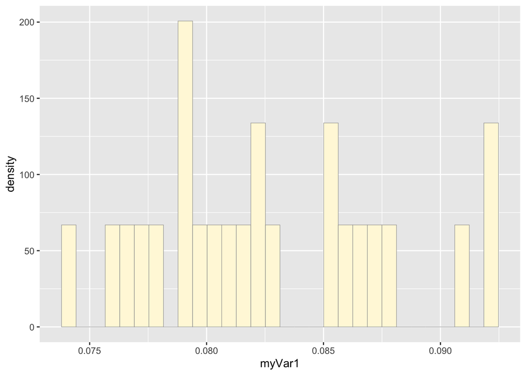

```r
p2 <- ggplot(data=z1, aes(x=myVar1, y=..density..)) +
  geom_histogram(color="grey60",fill="cornsilk",size=0.2)
print(p2)
```

Add the normal probability density curve to this simulated histogram:

```r
xval1 <- seq(0,max(z1$myVar1),len=length(z1$myVar1))

 stat1 <- stat_function(aes(x = xval1, y = ..y..), fun = dnorm, colour="red", n = length(z$myVar), args = list(mean = meanML, sd = sdML))
 p2 + stat1
```

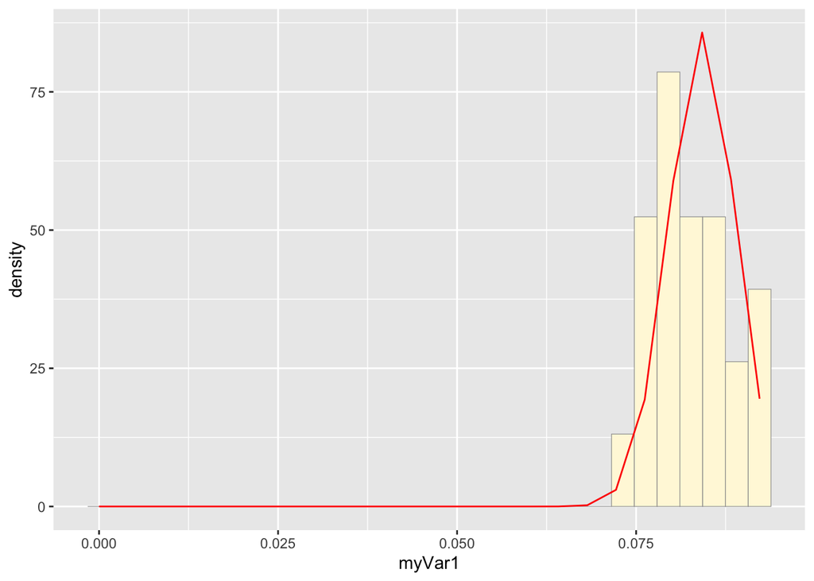

Plotting a histogram of my original data again to compare it to the simulated vesion:

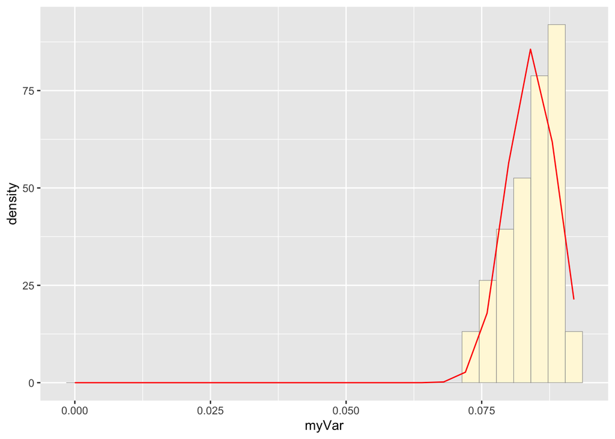

```r
# generating the histogram plot of my data
p1 <- ggplot(data=z, aes(x=myVar, y=..density..)) +
  geom_histogram(color="grey60",fill="cornsilk",size=0.2)

# generating the normal probability distribution curve and adding it to the histogram...
meanML <- normPars$estimate["mean"]
sdML <- normPars$estimate["sd"]

xval <- seq(0,max(z$myVar),len=length(z$myVar))

 stat <- stat_function(aes(x = xval, y = ..y..), fun = dnorm, colour="red", n = length(z$myVar), args = list(mean = meanML, sd = sdML))
 p1 + stat
```

The simulated histogram does a good job of simulating my original data. The actual normal probability curves are very similar. My data set is small, but I think if I simulated a larger data set, the simulation would do even better at generating realistic data. My original data appears to be more “normally distributed” than the simulation data set (the original data lies more in a normal curve, with fewer large density increases or drops between histogram bars), but the overall normal curve trend seems to be the same.